# Liberty Mutual Challenge

Kevin Gunn

February 14, 2019

## Exploratory Data Analysis and Feature Engineering

Load data and necessary libraries in R.

```r
library(glmnet)
library(gbm)
library(purrr)
library(caret)
library(DMwR)
library(pROC)
library(gridExtra)
library(FactoMineR)
library(factoextra)
library(reshape2)
library(ggplot2)
library(knitr)
library(randomForest)
library(dplyr)
library(readr)

CED <- read_csv("C:/Users/kpgunn/Documents/LibMut/CodingExerciseDataset.csv")
```

### Part (A)

Next, let’s summarize the dataset.

```r
dim(CED)
```

[1] 8000 81

```r
# Find number of demographic variables. This is the last column with demographic information.
which(colnames(CED)=="purchase_pwr_cls")
```

[1] 38

```r
#PU - Montary columns
which(colnames(CED)=="contrib_ss") - which(colnames(CED)=="purchase_pwr_cls")
```

[1] 21

```r
#PU - Quantity columns
which(colnames(CED)=="num_ss") - which(colnames(CED)=="contrib_ss")
```

[1] 21

There are 8,000 customers, 80 explanatory variables, and 1 response variable. There are 38 demographic variables and 42 Product Usage variables. The first 21 product usage variables are related to monetary contributions to different types of insurance policies. The last 21 product usage variables are related to number of different types of insurance policies owned.

```r
# Check for missing data but there is no missing data.
#colMeans(is.na(CED))

all(apply(CED,2,is.character))
```

```
## [1] TRUE
```

The variables are all characters in R, but we should transform them to factors for our analysis. Most variables are ordinal based on the data dictonary provided. There are no missing data present in this data set.

```r
CEDf <- as.data.frame(sapply(CED, as.factor))

unique_factor_levels = apply(CEDf,2,function(x){length(unique(x))})
count_vars_df = as.data.frame(table(unique_factor_levels))
names(count_vars_df)[1] = 'Lvls'

kable(count_vars_df, format = "html",caption = "Distribution of Unique Levels")
```

Distribution of Unique Levels

| Lvls | Freq |
| --- | --- |
| 2 | 6 |
| 3 | 7 |
| 4 | 6 |
| 5 | 8 |
| 6 | 11 |
| 7 | 5 |
| 8 | 4 |
| 9 | 3 |
| 10 | 31 |

```r
pt = prop.table(table(CEDf$mobile_home_policy))
pt_frame=as.data.frame(pt)
names(pt_frame)[1] = 'Response'

kable(pt_frame, format = "html",caption = "Mobile Home Policy Proportions")
```

Mobile Home Policy Proportions

| Response | Freq |
| --- | --- |
| 0 | 0.94125 |
| 1 | 0.05875 |

The proportion of customers with a mobile home policy is roughly 5%. This is a small proportion of the customers in this data set and the model development portion of this challenge will need to adapt for this issue.

### Part (B)

In this section, 2-3 visual artifacts will be provided to find the most important relationships between variables. First, multi-factorial analysis will be performed to look at the three groups of variables (Demograhics, Product Usage - Monetary, Product Usage - Quantity). Next, we’ll look at variable importance using random forests to get an idea of the variables useful in a predictive model. Last, local linear embedding is used to discover any nonlinear structure within the data.

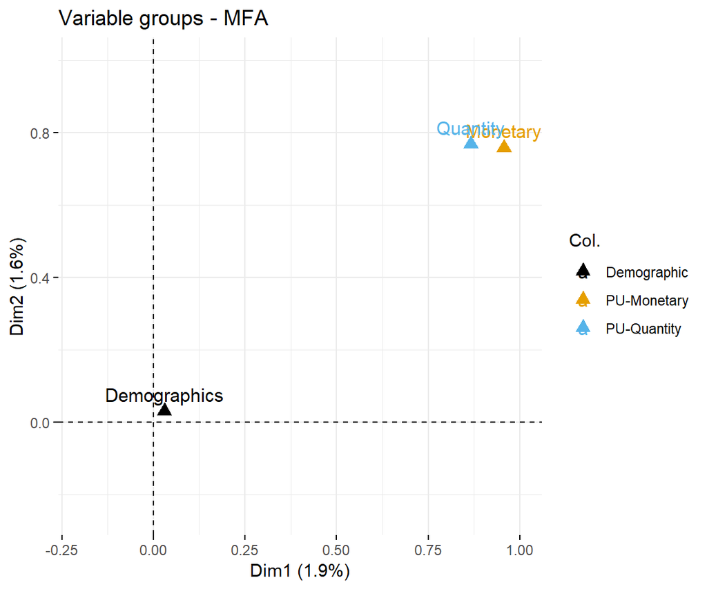

```r
# Matrix of just independent variables.
X = as.data.frame(CEDf[,-81])

MFA_X = MFA(X, group=c(38,21,21), type=rep("n",3) , ncp=5,
            name.group=c("Demographics", "Monetary","Quantity"),
            graph=FALSE)

# Color palette:
cbb <- c("#000000", "#E69F00", "#56B4E9", "#009E73", "#F0E442", "#0072B2", "#D55E00", "#CC79A7")

# Examine Variable groups that contribute to variation within Eigenvectors.
fviz_mfa_var(MFA_X, "group", palette = cbb, col.var = c("Demographic","PU-Monetary","PU-Quantity"),xlim=c(-0.2,1),ylim = c(-0.25,1))
```

The plot above illustrates the correlation between groups and the first two principal components. The variables within the groups “Product Usage - Monetary” and “Product Usage - Quantity” contriute the most to the variation within the data and are also highly correlated.

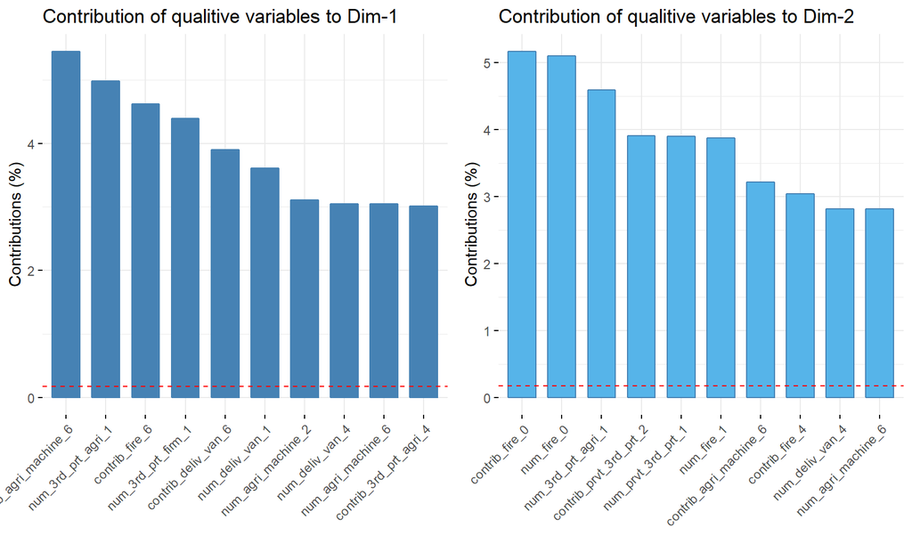

```r
# Examine variables that contribute the most to variation in Eigenvectors 1 and 2.
plot1 <- fviz_contrib(MFA_X, choice ="quali.var", axes = 1,top=10)

plot2 <- fviz_contrib(MFA_X, choice ="quali.var", axes = 2,top=10,fill="#56B4E9")

grid.arrange(plot1, plot2, ncol=2)
```

The bar plots show the actual variables contributing to the variation in the data. We will use Random Forests with synthetic minority over-sampling technique (SMOTE) to get an idea of the most important features when we are tasked with developing a predictive model. This is a first step in reducing the number of variables in our model to help create a more interpretable final model and to reduce time learning features that do not add to the predictive power of our models.

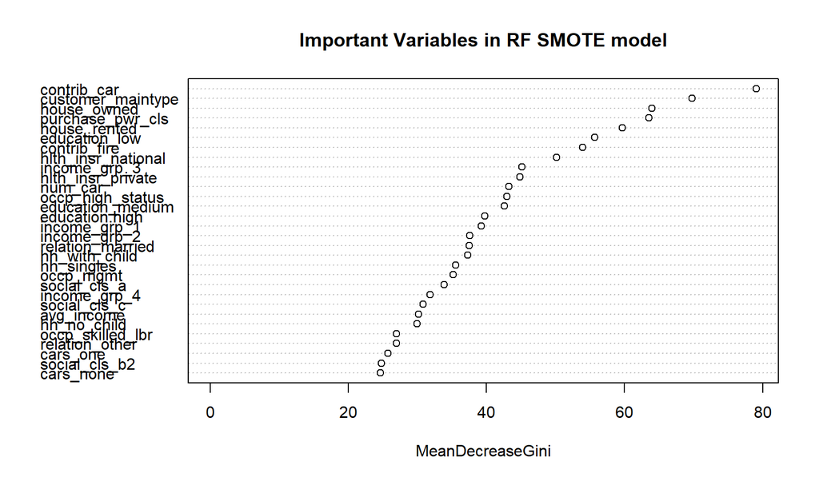

```r
# Feature Engineering and feature selection.

CED_SMOTE <- SMOTE(mobile_home_policy~., data=CEDf,k=5,
                   perc.under = 200,perc.over = 200)
# Variable Importance Measures
rf1 <- randomForest(mobile_home_policy ~ . ,data=CED_SMOTE)

varImpPlot(rf1, main="Important Variables in RF SMOTE model")
```

```r
Imp <- importance(rf1)

# After examining plot lets choose value with MDG > 20.
ImpVars<- rownames(Imp)[Imp>20]
```

Next, we’ll perform one-hot encoding so that we can use logistic regression. One-hot encoding also offers more interpretability when deteriming specific information pertinent for determining which type of customer is more likely to buy mobile home insurance. Variables with near zero variance will be removed.

```r
# Feature Engineering

# First reduce to only important variables.
CEDf2 <- CEDf[,which(colnames(CEDf) %in% ImpVars)]

# one-hot encoding with only features deemed important by RF.
dmy <- dummyVars(" ~ .", data = CEDf2)
CED.OH <- cbind( data.frame(predict(dmy, newdata = CEDf2)),
                 mobile_home_policy=CEDf$mobile_home_policy )

set.seed(123)

splitIndex <- createDataPartition(CED.OH$mobile_home_policy, p = .7,
                                  list = FALSE,
                                  times = 1)
trainSplit <- CED.OH[ splitIndex,]
testSplit <- CED.OH[-splitIndex,]

# Get rid of variables with small variance
ts_nzv <- nearZeroVar(trainSplit, saveMetrics = TRUE)
reduce_vars <- rownames(ts_nzv[which(ts_nzv$nzv=="TRUE"),])

trainSplit <- trainSplit[,-which(names(trainSplit) %in% reduce_vars) ]
testSplit <- testSplit[,-which(names(testSplit) %in% reduce_vars) ]

groupby_mhp <- trainSplit %>%
                  group_by(mobile_home_policy) %>%
                  summarise_all(mean)
cors <- melt(groupby_mhp[2,])
kable(cors[order(cors[,3],decreasing=TRUE)[1:20],-1],format = "html",caption = "Variables Most in Agreement with Mobile Home Policy",col.names = c("Variable","Agreement"))
```

Variables Most in Agreement with Mobile Home Policy

|  | Variable | Agreement |
| --- | --- | --- |
| 182 | contrib_car.6 | 0.7203647 |
| 188 | num_car.1 | 0.6504559 |
| 179 | contrib_prvt_3rd_prt.2 | 0.5683891 |
| 186 | contrib_fire.4 | 0.4468085 |
| 162 | income_grp_4.0 | 0.4285714 |
| 178 | contrib_prvt_3rd_prt.0 | 0.3981763 |
| 20 | hh_singles.0 | 0.3829787 |
| 167 | avg_income.4 | 0.3799392 |
| 124 | cars_none.0 | 0.3465046 |
| 183 | contrib_fire.0 | 0.3161094 |
| 122 | cars_one.7 | 0.3130699 |
| 17 | relation_other.2 | 0.3009119 |
| 143 | income_grp_1.0 | 0.3009119 |
| 12 | relation_married.7 | 0.2978723 |
| 85 | social_cls_b1.2 | 0.2948328 |
| 99 | house_rented.0 | 0.2948328 |
| 118 | house_owned.9 | 0.2948328 |
| 126 | cars_none.2 | 0.2917933 |
| 121 | cars_one.6 | 0.2857143 |
| 29 | hh_no_child.4 | 0.2796353 |

Next, we’ll use local linear embedding (LLE) to visualize the data in a lower dimensional space. LLE finds the k-nearest neighbors of each point. It minimizes the sum of squares of the local linear regression to obtain a weight matrix, $W$. LLE then treats $W$ as fixed, and optimizes a new cost function with an eigen solver to obtain the lower dimensional embedding.(https://cs.nyu.edu/~roweis/lle/papers/lleintro.pdf)

```r
library(lle)
set.seed(12345)
ycol = dim(trainSplit)[2]
Xm = as.matrix(trainSplit[,-ycol])

######## LLE
lleX = lle(Xm, m=2, k=5, reg = 2, ss = FALSE, p = 0.5, id = FALSE,
nnk = TRUE, eps = 1, iLLE = FALSE, v = 0.99)
```

```
## finding neighbours
## calculating weights
## computing coordinates
```

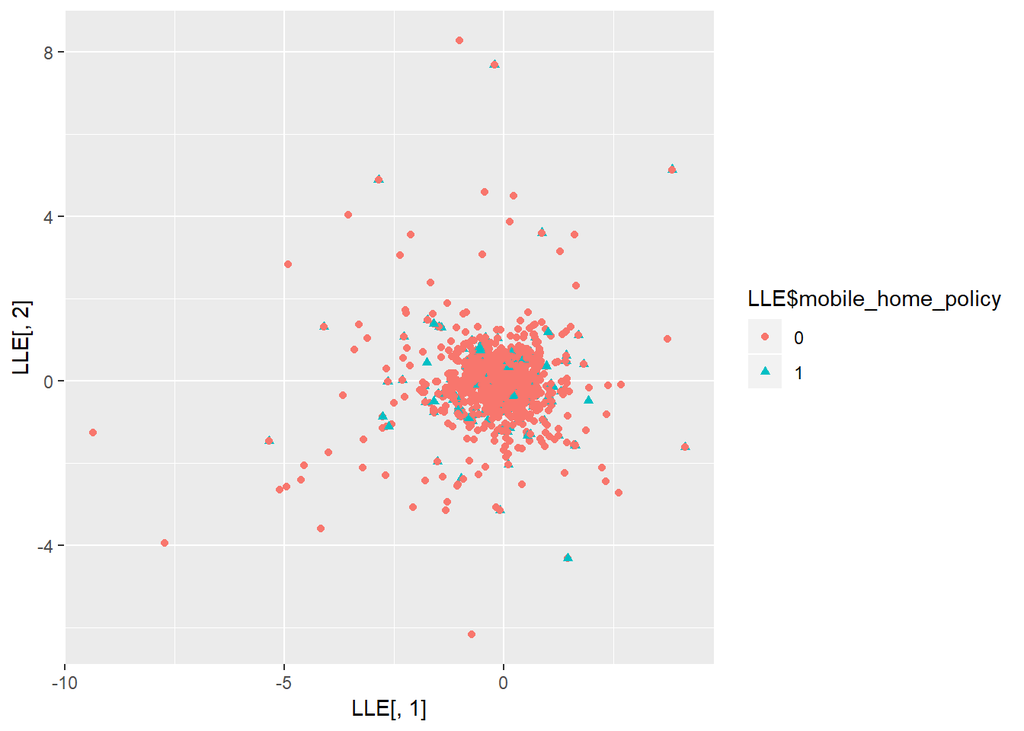

```r
LLE = as.data.frame(lleX$Y)
LLE$mobile_home_policy = trainSplit$mobile_home_policy

colnames(LLE) <- c(paste("L", 1:(dim(LLE)[2]-1), sep=""),"mobile_home_policy")

# The plot
ggplot(NULL,aes(x = LLE[,1], y = LLE[,2],  color = LLE$mobile_home_policy,shape = LLE$mobile_home_policy)) + geom_point()
```

Policy holders and non-policy holders are grouped together without any clear distinction between them. This sugests it may be difficult to accurately predict policy holders with the small amount of information we have on customers with mobile home policies.

## Model Building and Evaluation

Fitting a model on original data cannot predict what kind of customer is likely to buy mobile home insurance. To overcome this issue, we use case weights and synthetic minority over-sampling technique (SMOTE) in combination with gradient boosting and logistic regression with elastic net regularization.

```r
set.seed(12345)
# Set up control function for training

ctrl <- trainControl(method = "cv",
                     number = 5,
                     #repeats = 5,
                     #seeds=seeds,
                     summaryFunction = twoClassSummary,
                     classProbs = TRUE)


# Build a standard classifier using a gradient boosted machine

orig_gbm_fit <- train(make.names(mobile_home_policy) ~ .,
                  data = trainSplit,
                  method = "gbm",
                  verbose = FALSE,
                  metric = "ROC",
                  trControl = ctrl)

gbm_preds <- predict(orig_gbm_fit, testSplit,type = "raw")

orig_glmnet_fit <- train(make.names(mobile_home_policy) ~ .,
                    data = trainSplit,
                    method = "glmnet",
                    metric = "ROC",
                    tuneLength = 3,
                    trControl =  ctrl)

glmnet_preds <- predict(orig_glmnet_fit, testSplit,type = "raw")

# Tune Grid for GBM
gbmGrid <-  expand.grid(interaction.depth = c(1, 5, 9),
                        n.trees = (1:30)*50,
                        shrinkage = 0.1,
                        n.minobsinnode = 20)
# Build Weighted Model. Weights sum to 1.
model_weights <- ifelse(trainSplit$mobile_home_policy == 0,
                        (1/table(trainSplit$mobile_home_policy)[1]*0.5),
                        (1/table(trainSplit$mobile_home_policy)[2])*0.5)

# Build weighted model

weighted_gbm_fit <- train(make.names(mobile_home_policy) ~ .,
                      data = trainSplit,
                      method = "gbm",
                      verbose = FALSE,
                      weights = model_weights,
                      metric = "ROC",
                      tuneGrid = gbmGrid,
                      trControl = ctrl)

weighted_gbm_preds <- predict(weighted_gbm_fit, testSplit,type = "raw")


weighted_glmnet_fit <- train(make.names(mobile_home_policy) ~ .,
                      data = trainSplit,
                      method = "glmnet",
                      weights = model_weights,
                      metric = "ROC",
                      tuneLength=3,
                      trControl = ctrl)

weighted_glmnet_preds <- predict(weighted_glmnet_fit, testSplit,type = "raw")


# Build smote model
ctrl$seeds <- orig_glmnet_fit$control$seeds
ctrl$sampling <- "smote"

set.seed(12345)
smote_gbm_fit <- train(make.names(mobile_home_policy) ~ .,
                   data = trainSplit,
                   method = "gbm",
                   verbose = FALSE,
                   metric = "ROC",
                   tuneGrid = gbmGrid,
                   trControl = ctrl)

smote_gbm_preds <- predict(smote_gbm_fit, testSplit,type = "raw")

smote_glmnet_fit <- train(make.names(mobile_home_policy) ~ .,
                    data = trainSplit,
                    method = "glmnet",
                    metric = "ROC",
                    tuneLength = 3,
                    trControl =  ctrl)

smote_glmnet_preds <- predict(smote_glmnet_fit, testSplit,type = "raw")
```

### Evaluation Measures.

We’ll examine the AUC ROC and confusion matrices to decide on the best model. Measures such as accuracy are not as relevant since we will correctly predict most of the response values as “0”.

```r
# Confusion Matrices.

test_response = (make.names(testSplit$mobile_home_policy))
tr = as.factor(test_response)

# Original Fit without SMOTE.
confusionMatrix(glmnet_preds,  tr, positive = "X1")$table
```

```
##           Reference
## Prediction   X0   X1
##         X0 2259  141
##         X1    0    0
```

```r
confusionMatrix(gbm_preds, tr, positive = "X1")$table
```

```
##           Reference
## Prediction   X0   X1
##         X0 2258  139
##         X1    1    2
```

```r
# Fit with SMOTE.
confusionMatrix(smote_gbm_preds, tr, positive = "X1")$table
```

```
##           Reference
## Prediction   X0   X1
##         X0 1917   77
##         X1  342   64
```

```r
confusionMatrix(smote_glmnet_preds, tr, positive = "X1")$table
```

```
##           Reference
## Prediction   X0   X1
##         X0 1767   62
##         X1  492   79
```

```r
# Fit with Weights.
confusionMatrix(weighted_gbm_preds,tr,positive = "X1")$table
```

```
##           Reference
## Prediction   X0   X1
##         X0 1493   43
##         X1  766   98
```

```r
confusionMatrix(weighted_glmnet_preds,tr,positive = "X1")$table
```

```
##           Reference
## Prediction   X0   X1
##         X0 1590   47
##         X1  669   94
```

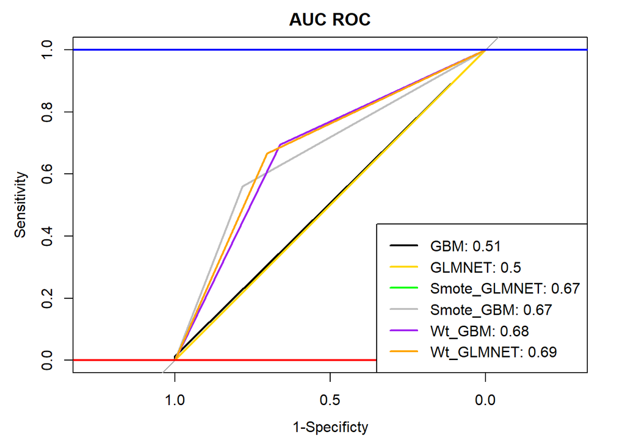

```r
# AUC ROC curve.

# Examine results for test set

auc_of_gbm <- roc(as.numeric(testSplit$mobile_home_policy), as.numeric(gbm_preds))

auc_of_glmnet <- roc(as.numeric(testSplit$mobile_home_policy),
                     as.numeric(glmnet_preds))

auc_smote_glmnet <- roc(as.numeric(testSplit$mobile_home_policy),
                        as.numeric(smote_glmnet_preds))

auc_smote_gbm <- roc(as.numeric(testSplit$mobile_home_policy),
                     as.numeric(smote_glmnet_preds))

auc_wt_gbm <- roc(as.numeric(testSplit$mobile_home_policy),
                  as.numeric(weighted_gbm_preds))

auc_wt_glmnet <- roc(as.numeric(testSplit$mobile_home_policy),
                     as.numeric(weighted_glmnet_preds))

plot(auc_of_gbm, ylim=c(0,1), print.thres=FALSE, main="AUC ROC",xlab="1-Specificty")
lines(auc_of_glmnet,col="gold")
lines(auc_smote_glmnet,col="green")
lines(auc_smote_gbm,col="grey")
lines(auc_wt_gbm,col="purple")
lines(auc_wt_glmnet, col="orange")
abline(h=1,col='blue',lwd=2)
abline(h=0,col='red',lwd=2)

colors_leg <- c("black","gold","green","grey","purple","orange")
leg <- c(paste('GBM:',round(auc_of_gbm$auc[[1]],2)),
        paste('GLMNET:',round(auc_of_glmnet$auc[[1]],2)),
        paste('Smote_GLMNET:',round(auc_smote_glmnet$auc[[1]],2)),
        paste('Smote_GBM:',round(auc_smote_gbm$auc[[1]],2)),
        paste('Wt_GBM:',round(auc_wt_gbm$auc[[1]],2)),
        paste('Wt_GLMNET:',round(auc_wt_glmnet$auc[[1]],2))
        )

legend("bottomright",leg,col = colors_leg,lwd=2 )
```

## Result Interpretation and Business Recommendation

```r
sum_wgbm <- summary(weighted_gbm_fit,plotit = FALSE)

important_vars <- sum_wgbm[which(sum_wgbm$rel.inf>0),]

ivs <- c(as.character(important_vars$var),"mobile_home_policy")

trainSplit_reduce <- trainSplit[,which(names(trainSplit) %in% ivs) ]
testSplit_reduce <- testSplit[,which(names(testSplit) %in% ivs) ]

important_vars
```

```
##                                           var    rel.inf
## contrib_car.6                   contrib_car.6 44.5456931
## contrib_fire.4                 contrib_fire.4 16.1586305
## avg_income.3                     avg_income.3  4.5611159
## avg_income.2                     avg_income.2  3.1357867
## income_grp_4.0                 income_grp_4.0  3.0688521
## contrib_prvt_3rd_prt.0 contrib_prvt_3rd_prt.0  2.8644993
## contrib_prvt_3rd_prt.2 contrib_prvt_3rd_prt.2  2.3836394
## purchase_pwr_cls.7         purchase_pwr_cls.7  2.3198425
## income_grp_1.5                 income_grp_1.5  1.8148914
## education.high.0             education.high.0  1.6869047
## income_grp_1.4                 income_grp_1.4  1.6696431
## house_rented.0                 house_rented.0  1.5030093
## contrib_car.5                   contrib_car.5  1.3706099
## income_grp_3.1                 income_grp_3.1  1.3038182
## education_low.9               education_low.9  1.2323322
## customer_maintype.B       customer_maintype.B  1.1934423
## cars_one.4                         cars_one.4  1.1845094
## relation_married.4         relation_married.4  1.1185518
## income_grp_1.2                 income_grp_1.2  1.0724775
## education_low.7               education_low.7  1.0715121
## occp_mgmt.2                       occp_mgmt.2  1.0369078
## occp_unskilled_lbr.0     occp_unskilled_lbr.0  1.0186401
## hlth_insr_national.6     hlth_insr_national.6  0.9772829
## house_owned.7                   house_owned.7  0.9434835
## customer_maintype.J       customer_maintype.J  0.7639241
```

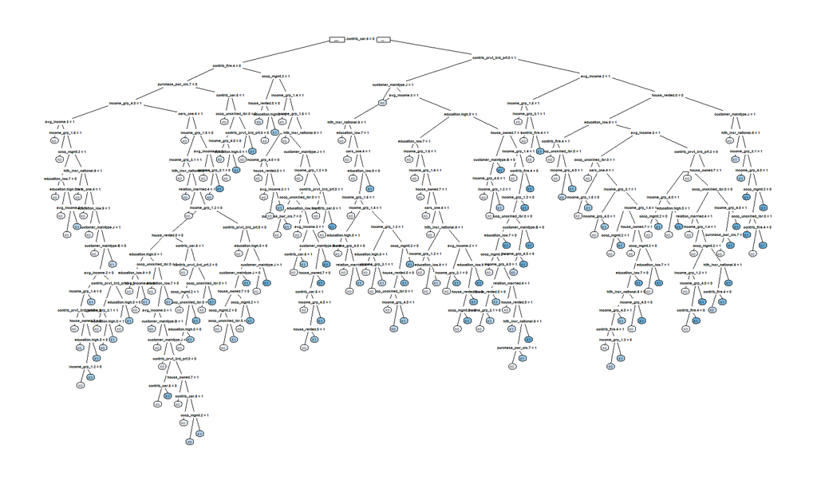

```r
library(rpart.plot)
set.seed(12345)
#ctrl$sampling <- "smote"
ctrl$sampling <- NULL
dtree_fit <- train(make.names(mobile_home_policy) ~.,
                   data = trainSplit_reduce,
                   method = "rpart",
                   metric = "ROC",
                   parms = list(split = "gini"),
                   weights = model_weights,
                   trControl=ctrl,
                   tuneLength = 10)

#dtree_preds <- predict(dtree_fit, testSplit_reduce,type = "raw")
#auc_dtree <- roc(as.numeric(testSplit$mobile_home_policy),
#                     as.numeric(dtree_preds))
#print(auc_dtree)

prp(dtree_fit$final, box.palette = "Blues", tweak = 1.5)
```

Contribution to car policies within the range of 1000-4999 is the most important factor in determining if a customer has a mobile home policy. Contribution to fire policies within 200-499 is the second most important factor for our prediction model. The variables average income within the $3^{rd}$ bracket and contribution to private third party insurance within the range 50-99 are good indicators for determining which type of customer is more likely to buy mobile home insurance.